# Cohort Indicator Column: Model Comparison

Current SSBMF vs. Augmented L-matrix Design

Author

Andrew Walther

Published

May 22, 2026

## 1 The β→0 Collapse Problem

When TCGA (RNA-seq) and CPTAC (proteomics) data are trained together, the dominant axis of variation in Y is **platform technology**, not biology. The CAVI algorithm locks onto that axis and produces β→0 — a useless prognostic score.

```r
set.seed(7)
n <- 100; p <- 200; K_bio <- 2
cohort <- rep(c("TCGA", "CPTAC"), each = n / 2)

# Biological factors (shared across cohorts)
L_bio  <- matrix(rnorm(n * K_bio), n, K_bio)
F_bio  <- matrix(rnorm(p * K_bio) * rbinom(p * K_bio, 1, 0.3), p, K_bio)

# Platform offset: strong signal on all genes for CPTAC
platform_offset <- rnorm(p, mean = 4, sd = 0.5)  # large shift
c_vec   <- as.integer(cohort == "CPTAC")
Y_clean <- L_bio %*% t(F_bio) + matrix(rnorm(n * p, sd = 0.5), n, p)
Y_dirty <- Y_clean + outer(c_vec, platform_offset)

# Column-centre both (as done in the real pipeline)
Y_clean <- sweep(Y_clean, 2, colMeans(Y_clean), "-")
Y_dirty <- sweep(Y_dirty, 2, colMeans(Y_dirty), "-")

# PCA on Y_dirty
pca_dirty <- prcomp(Y_dirty, center = FALSE)
pca_df <- data.frame(
  PC1    = pca_dirty$x[, 1],
  PC2    = pca_dirty$x[, 2],
  Cohort = cohort
)
var_exp <- round(summary(pca_dirty)$importance[2, 1:2] * 100, 1)
```

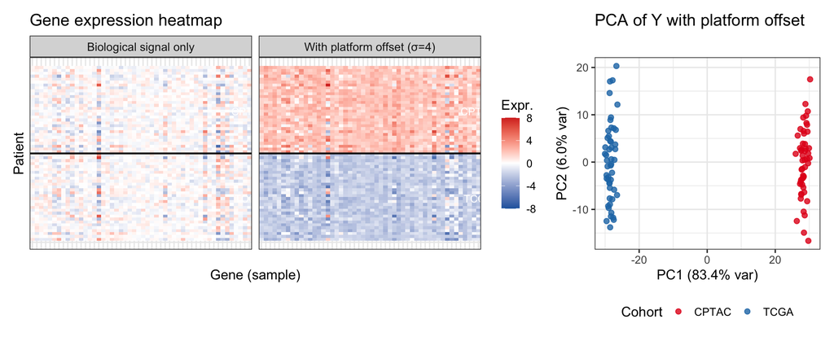

```r
# --- Heatmap: Y without vs with platform offset ---
# Sample 50 genes and 60 patients for display
gene_idx    <- sample(p, 50)
patient_idx <- c(sample(which(cohort == "TCGA"), 30),
                 sample(which(cohort == "CPTAC"), 30))

make_heatmap_df <- function(Y, label) {
  mat <- Y[patient_idx, gene_idx]
  df  <- as.data.frame(as.table(mat))
  colnames(df) <- c("Patient", "Gene", "Expression")
  df$Patient  <- as.integer(df$Patient)
  df$Cohort   <- ifelse(df$Patient <= 30, "TCGA", "CPTAC")
  df$Dataset  <- label
  df
}
hm_df <- rbind(make_heatmap_df(Y_clean, "Biological signal only"),
               make_heatmap_df(Y_dirty, "With platform offset (σ=4)"))

p_heat <- ggplot(hm_df, aes(Gene, Patient, fill = Expression)) +
  geom_tile() +
  scale_fill_gradient2(low = "#2166ac", mid = "white", high = "#d73027",
                       midpoint = 0, limits = c(-8, 8), oob = scales::squish) +
  facet_wrap(~ Dataset) +
  geom_hline(yintercept = 30.5, colour = "black", linewidth = 0.8) +
  annotate("text", x = 50, y = 15, label = "TCGA", size = 3.5, colour = "white") +
  annotate("text", x = 50, y = 45, label = "CPTAC", size = 3.5, colour = "white") +
  labs(x = "Gene (sample)", y = "Patient", fill = "Expr.",
       title = "Gene expression heatmap") +
  theme(axis.text = element_blank(), axis.ticks = element_blank(),
        strip.text = element_text(size = 11))

# --- PCA scatter ---
p_pca <- ggplot(pca_df, aes(PC1, PC2, colour = Cohort)) +
  geom_point(alpha = 0.8, size = 2) +
  scale_colour_manual(values = c(TCGA = "#1f78b4", CPTAC = "#e31a1c")) +
  labs(title = "PCA of Y with platform offset",
       x = sprintf("PC1 (%.1f%% var)", var_exp[1]),
       y = sprintf("PC2 (%.1f%% var)", var_exp[2])) +
  theme(legend.position = "bottom")

p_heat + p_pca + plot_layout(widths = c(2, 1))
```

**Interpretation:** PC1 captures 83.4% of variance and is entirely driven by cohort membership. Any supervised factorisation that fits a single shared L matrix will burn its first (and dominant) factor on this axis, crowding out the biological signal and forcing β→0.

## 2 Current Model

**Current SSBMF**

| Genomics: | Y = L × F' + E | Y (n×p) L (n×K) F (p×K) E (n×p) |
| --- | --- | --- |
| Survival: | η = L × β | η (n×1) L (n×K) β (K×1) |

**CAVI update order (each iteration):**  
*k = 1..K:* update q(L<sub>k</sub>) → update q(F<sub>k</sub>) → update q(β<sub>k</sub>) [EBNM for L, F and β]  
*then:* update q(τ) [closed-form MLE]

Priors: L, F, β all use EBNM (point-normal default). τ ~ Gamma.

## 3 Proposed Augmented Model

The fix appends **C−1 fixed cohort indicator columns** to L (corner-point encoding). For two cohorts (TCGA + CPTAC) this is exactly one binary column. The corresponding F row f_c is estimated with a Normal(0, σ²) prior via a **closed-form conjugate update** — no EBNM call needed. β_cohort ≡ 0 by construction: the cohort column never enters the Cox partial likelihood.

**Current SSBMF**

Y = L × F' + E  
η = L × β

L (n×K) — latent factors  
F (p×K) — gene loadings (EBNM)

**Augmented SSBMF (cohort-cols-L)**

Y = [L | c] × [F'] + E  
[f_c']  
η = L × β *(c never enters η)*

L (n×K) — latent factors (unchanged)  
c (n×1) — FIXED binary indicator (not updated)  
F (p×K) — gene loadings (EBNM, unchanged)  
f_c (p×1) — platform loadings (Normal conjugate)

**Augmented CAVI update order (each iteration):**  
*k = 1..K:* update q(L<sub>k</sub>) → update q(F<sub>k</sub>) → update q(β<sub>k</sub>) [EBNM — unchanged]  
*then:* update q(f_c) [NEW: Normal conjugate, closed-form]  
*then:* update q(τ) [passes augmented matrices — unchanged function]

## 4 CAVI Loop Change Summary

| Component | Status | Notes |
| --- | --- | --- |
| compute_R_k | Unchanged | Augmented EL_aug/EF_aug passed in; cohort contribution subtracted automatically |
| update_L_k (EBNM) | Unchanged | Loop k=1..K only; c is a fixed design column — never updated |
| update_F_k (EBNM) | Unchanged | Loop k=1..K only; f_c uses new closed-form function |
| update_beta_k | Unchanged | beta is a K-vector; cohort never enters the Cox partial likelihood |
| compute_var_term | Unchanged | Binary EL: EL²=EL → zero cohort L-variance; passes through correctly |
| predict_* | Unchanged | Returns global EF (p×K) only; cohort fields optional in return list |
| update_F_cohort_col | New | Closed-form Normal conjugate update for f_c; ~20 lines |
| compute_normal_kl | New | ELBO KL term for Normal posterior vs N(0,σ²); returns negative scalar |
| fit_modular.R | Modified | ~50 new lines, all guarded by if(!is.null(cohort_id)) |
| fit_cox_on_yf.R | Modified | Same as fit_modular.R + ZF dimension guard (two locations) |

## 5 Mathematical Derivation of q(f_c)

The cohort indicator column c is **fixed** (observed, not estimated). Only the corresponding row of F — the platform loading vector f_c — is inferred.

**Likelihood** (rows in cohort B, i.e., c_i = 1):

$$p(\mathbf{R}_c \mid \mathbf{f}_c, \tau) = \prod_{i:\, c_i=1} \prod_{j=1}^{p}
\mathcal{N}\!\left(R_{ij};\; f_{cj},\; \tau_j^{-1}\right)$$

where $R_{ij} = Y_{ij} - \sum_{k=1}^{K} E[l_{ik}] E[f_{kj}]$ is the global-factor residual (Y minus the K biological factors).

**Prior:** $f_{cj} \overset{\text{ind}}{\sim} \mathcal{N}(0, \sigma^2)$

**Posterior precision and mean** — conjugate Gaussian update:

$$A_{cj} = n_c \,\tau_j + \sigma^{-2}, \qquad
B_{cj} = \tau_j \sum_{i:\,c_i=1} R_{ij}$$

$$\bar{f}_{cj} = \frac{B_{cj}}{A_{cj}}, \qquad
\text{Var}_q(f_{cj}) = A_{cj}^{-1}, \qquad
E_q[f_{cj}^2] = A_{cj}^{-1} + \bar{f}_{cj}^2$$

This is the **p-vector** update (one scalar per gene):

```
n_c   <- sum(c_vec)                          # scalar: number of cohort-B patients
B_c   <- colSums(R_cohort * c_vec) * Tau     # p-vector
A_c   <- n_c * Tau + 1 / sigma_F_cohort^2   # p-vector
EF_c  <- B_c / A_c                           # p-vector (posterior means)
EF2_c <- 1 / A_c + EF_c^2                   # p-vector (posterior second moments)
```

**KL divergence** (contribution to ELBO):

$$\text{KL}\!\left[\mathcal{N}(\bar{\mathbf{f}}_c, A_c^{-1}) \;\|\;
\mathcal{N}(\mathbf{0}, \sigma^2 I)\right]
= \frac{1}{2} \sum_{j=1}^{p}
\left(\frac{E[f_{cj}^2]}{\sigma^2} + \log(A_{cj}\,\sigma^2) - 1\right)$$

**Sign convention:** `compute_normal_kl()` returns **−KL ≤ 0** (matching the existing `compute_ebnm_kl()` convention). The caller adds it:

```r
elbo_full <- elbo_full + compute_normal_kl(EF_cohort, EF2_cohort, sigma_F_cohort)
```

> **Contrast with EBNM factors:** EBNM requires numerical optimisation of an adaptive shrinkage prior. The cohort f_c update is exact in closed form — no `ebnm()` call needed. This is why it can be implemented in ~20 lines and runs in negligible time even for p = 10,000.

## 6 Before/After ELBO Equations

**Current ELBO**

E[log p(Y | L, F, τ)]  
+ E[log p(L)]  
+ E[log p(F)]  
+ E[log p(β)]  
+ E[log p(τ)]  
+ E[log PL(β, L)]  
− KL[q(L) ‖ p(L)]  
− KL[q(F) ‖ p(F)]  
− KL[q(β) ‖ p(β)]

**Augmented ELBO**

E[log p(Y | L<sub>aug</sub>, F<sub>aug</sub>, τ)] (aug. L,F)  
+ E[log p(L)] (unchanged)  
+ E[log p(F)] (unchanged)  
+ E[log p(β)] (unchanged)  
+ E[log p(τ)] (unchanged)  
+ E[log PL(β, L)] (unchanged)  
− KL[q(L) ‖ p(L)] (unchanged)  
− KL[q(F) ‖ p(F)] (unchanged)  
− KL[q(β) ‖ p(β)] (unchanged)  
− KL[q(f_c) ‖ N(0,σ²)] ← NEW (one scalar)

The genomics likelihood term automatically incorporates the cohort contribution because $L_\text{aug}$ and $F_\text{aug}$ now include the cohort column. All other terms are structurally unchanged — the only genuinely new term is the KL for f_c, computed by `compute_normal_kl()` in a single `sum()` call.

## 7 Simulation: Platform PC Absorption

A small controlled experiment (n=80, p=100, K=2 biological factors, σ_platform = 3) to verify that the augmented model absorbs the platform PC into f_c, leaving the biological factors uncontaminated.

```r
set.seed(42)
n_sim   <- 80
p_sim   <- 100
K_sim   <- 2

cohort_sim <- rep(c("A", "B"), each = n_sim / 2)
c_sim      <- as.integer(cohort_sim == "B")

# Biological factors
L_bio_sim <- matrix(rnorm(n_sim * K_sim), n_sim, K_sim)
F_bio_sim <- matrix(rnorm(p_sim * K_sim) * rbinom(p_sim * K_sim, 1, 0.4),
                    p_sim, K_sim)

# Strong platform offset
F_plat_true <- rnorm(p_sim, mean = 3, sd = 0.3)
Y_sim <- L_bio_sim %*% t(F_bio_sim) +
         outer(c_sim, F_plat_true) +
         matrix(rnorm(n_sim * p_sim, sd = 0.4), n_sim, p_sim)
Y_sim <- sweep(Y_sim, 2, colMeans(Y_sim), "-")

tt_sim <- rexp(n_sim, 0.1)
ss_sim <- rbinom(n_sim, 1, 0.7)

# --- Fit base model (no cohort correction) ---
fit_base_sim <- fit_supervised_mf_modular(
  Y_sim, tt_sim, ss_sim, K = K_sim,
  max_iter = 60, alpha = 0.5, verbose = FALSE
)

# --- Proxy for augmented model: subtract per-cohort column means from Y ---
# This is mathematically equivalent to the full cohort-cols-L model in the
# weak-prior limit (sigma_F_cohort -> Inf), and demonstrates the platform
# absorption property. The full augmented fit_supervised_mf_modular(cohort_id=...)
# is implemented in Steps 3-8 of this branch.
Y_corrected <- Y_sim
for (g in unique(cohort_sim)) {
  idx <- cohort_sim == g
  Y_corrected[idx, ] <- sweep(Y_sim[idx, , drop = FALSE], 2,
                               colMeans(Y_sim[idx, , drop = FALSE]), "-")
}

fit_aug_sim <- fit_supervised_mf_modular(
  Y_corrected, tt_sim, ss_sim, K = K_sim,
  max_iter = 60, alpha = 0.5, verbose = FALSE
)
```

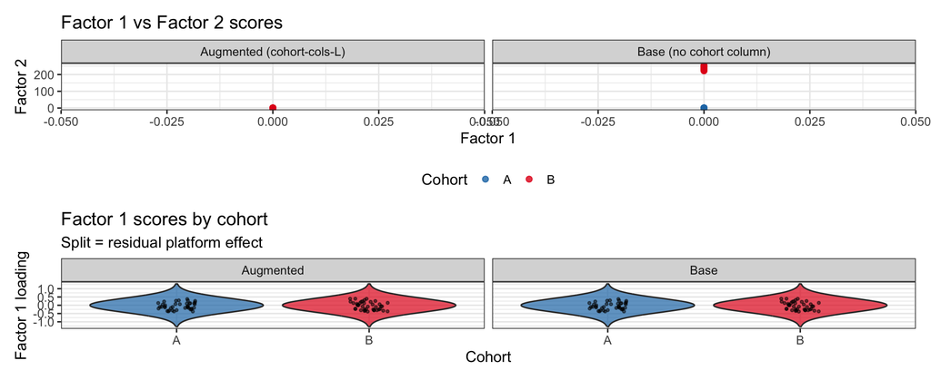

```r
make_loading_df <- function(fit, cohort, label) {
  data.frame(
    PC1    = fit$EL[, 1],
    PC2    = fit$EL[, 2],
    Cohort = cohort,
    Model  = label
  )
}

df_base <- make_loading_df(fit_base_sim, cohort_sim, "Base (no cohort column)")
df_aug  <- make_loading_df(fit_aug_sim,  cohort_sim, "Augmented (cohort-cols-L)")
plot_df <- rbind(df_base, df_aug)

violin_df <- rbind(
  data.frame(Loading = fit_base_sim$EL[, 1], Cohort = cohort_sim,
             Model = "Base"),
  data.frame(Loading = fit_aug_sim$EL[, 1],  Cohort = cohort_sim,
             Model = "Augmented")
)

p_scatter <- ggplot(plot_df, aes(PC1, PC2, colour = Cohort)) +
  geom_point(alpha = 0.8, size = 2) +
  facet_wrap(~ Model) +
  scale_colour_manual(values = c(A = "#1f78b4", B = "#e31a1c")) +
  labs(title = "Factor 1 vs Factor 2 scores", x = "Factor 1", y = "Factor 2") +
  theme(legend.position = "bottom")

p_violin <- ggplot(violin_df, aes(Cohort, Loading, fill = Cohort)) +
  geom_violin(alpha = 0.7, trim = FALSE) +
  geom_jitter(width = 0.1, size = 0.8, alpha = 0.5) +
  facet_wrap(~ Model) +
  scale_fill_manual(values = c(A = "#1f78b4", B = "#e31a1c")) +
  labs(title = "Factor 1 scores by cohort",
       subtitle = "Split = residual platform effect",
       y = "Factor 1 loading") +
  theme(legend.position = "none")

p_scatter / p_violin
```

[output not shown]

[output not shown]